# Exploratory Analysis

## Voting Participation

### Authors

Matthew Lalangan (lalangan@uw.edu)  
Savanna Olsen (savannaq@uw.edu)  
Henry Wiseman (hwise1@uw.edu)  
Jonny Sung (jsung5@uw.edu)

### Date

Spring 2024

### Abstract

Our main question is how political views and voter registration affect civic participation. This is a crucial question since knowing these things provides insight on political and societal developments. In order to answer this issue, we will examine voter registration statistics from various cities, monitor the party shift in Washington over time, and examine voter turnout and political affiliations between states in order to uncover more general trends in civic engagement and public opinion.

### Keywords

Keywords: Washington State, Voter Demographics, Counties, Cities

### Introduction

Which city has the highest voter turnout?

Which gender has a higher voter turnout?

How might Washington’s demographics be helpful in predicting demographics in the U.S?

The topic of civic engagement has many large implications and important questions. The data can give insight into trends in public opinion. One important question is simply how many people register in each city. Cities in Washington and the US in general, have vastly differing populations and political views. By understanding the number of people registering to vote in different cities, you can observe which areas and groups of people feel more inclined to vote. Another important question is how the gender of voter turnout varies across counties. Learning what areas of the state show trends of a certain gender voting more could help to identify what factors are in play. This trend could raise many questions about how Washington fits into national trends. It could also explain changes in the state itself. The last important question raised by this data is how Washington compares to other states in voter turnout and political beliefs. Understanding voter trends is an incredibly important aspect of a democratic system. Knowledge of these trends can reveal areas of unrest and anger among the people. Voter turnout and political affiliation can vary greatly with the changing of topics in public discussion. By analyzing and interpreting voter data, a greater understanding of public belief and social values can be achieved.

### Related Work

The topic of civic engagement and voter behavior can be crucial in understanding the dynamics of democracy and public opinion. Scholars and researchers have examined various aspects of this subject, utilizing data to reveal trends, patterns, and potential implications. It is important to understand voter registration and turnout in order to evaluate the level of civic engagement in a community or nation. Details on voter behavior can be gained from reports like the Washington Secretary of State’s “General Election Turnout” as well as data from state election boards and the U.S. Census Bureau. For example, recent reports from the Washington Secretary of State indicate shifts in voter turnout, with some elections experiencing modern lows in participation rates, as highlighted in Alison Saldanha’s article in The Seattle Times. Another important part is examining how political opinions and partisanship have changed throughout time. Opinion surveys, comparative analyses between regions, and ongoing studies are frequently used by researchers to monitor shifts in voter preferences. FOX13 News reported on recent statistics from the 2024 Presidential Primary in Washington, which provides insight into regional differences in ideologies and party support and offers data on how different counties voted. Related work in this space includes academic research articles, government reports like those published by the Washington Secretary of State, and media coverage from outlets such as The Seattle Times and FOX13 News. These resources add to the continuing discussion about voter behavior and civic involvement, which deepens our understanding of how democracies work and the opportunities and challenges they bring.

“General Election Turnout.” General Election Turnout | WA Secretary of State, www.sos.wa.gov/elections/data-research/election-data-and-maps/reports-data-and-statistics/general-election-turnout. Accessed 1 May 2024.

Saldanha, Alison. “Did You Vote? A Lot of Your Neighbors Didn’t.” The Seattle Times, The Seattle Times Company, 28 Nov. 2023, www.seattletimes.com/seattle-news/voter-turnout-hits-modern-low-in-wa/.

Seattle, FOX 13. “How Every WA County Voted in the 2024 Presidential Primary.” FOX13 News | Seattle & Western Washington | Formerly Q13 News, FOX13 News | Seattle & Western Washington | Formerly Q13 News, 13 Mar. 2024, www.fox13seattle.com/election/wa-primary-results-county.

### The Dataset

Where did you find the data? Please include a link to the data source

> Dataset: [City Registration Table](https://www.sos.wa.gov/elections/data-research/election-data-and-maps/reports-data-and-statistics/voter-demographics)

Who collected the data?

> Washington Secretary of State

How was the data collected or generated?

> The Secretary of State records data when people register to vote.

Why was the data collected?

> The voter demographics are collected to ensure fair representation, shape policies, strategize elections, and study voting behavior.

How many observations (rows) are in your data?

> There are 328 rows

How many features (columns) are in the data?

> There are 5 features

What, if any, ethical questions or questions of power do you need to consider when working with this data?

> Voter registration data contains sensitive information, such as names, addresses, and voting history. It is essential to handle this data with care and ensure that individuals’ privacy is protected. Furthermore, we should be aware of potential biases in the data, such as underrepresentation of certain demographic groups, and take steps to mitigate these biases in our analysis.

What are possible limitations or problems with this data?

> For the most part, the data is truthful and accurate since it is recorded by the government. However, voter demographics are input by people, so there could be inaccuracies due to human error. For example, voters might accidentally fill in the wrong bubble or other personal information. Also, the data may not fully reflect the complexity of voter demographics since people may not fit exactly into the categories provided, or simply opt out of submitting some information. Voter demographics are usually updated every year or in other specific intervals, and may be inaccurate if voters are not regularly updating their government registrations, so the data would become outdated quickly. This could especially be the case for counties and cities where population mobility is high, or in election years in which voter registration becomes intensified. Some of the registered voters could also be inactive because they moved away or just disengaged from the electoral process, so their data would lead to inaccuracies in predicting voter preference. One last concern could be data manipulation or tampering, where voter registration systems or people try to manipulate the demographics for political benefit. Though this is unlikely as government information has higher levels of security, it is still a possibility that could affect the data.

### Implications

Possible implications for technologists include the development of better systems of data collection, reducing the level of human error, including measures that detect and prevent data manipulation and tampering, and systems that update voter demographics in real time to reduce outdated information. User-friendly systems with a good design and proper instructions could go a long way in minimizing errors. Systems to keep real-time records of voter information could also result in consistently reliable data. The collaboration between technologists and designers is going to be very important to identify ways to locate and eliminate inactive voters and increase the number of citizens into active voter participation in the electoral process. This could be troublesome for policymakers to devise effective strategies of changing voters’ mind in case the demographics happen to be wrong. They might have to rely on errors on the collected data or, alternatively, direct more energy to ensuring that the data collected is correct and safe. Again, the implications with government recorded data are very few apart from human recorded error. Still, technologists, designers, and policymakers can work up innovations to tackle the issue.

### Limitations & Challenges

Throughout the course of this challenge, there may be a variety of challenges and limitations that arise. One limitation would be that access to voter registration and election result data may be limited or restricted due to data protection regulations or simply due to human error. Missing data, especially in demographic variables, can pose challenges when analyzing voter demographics. Thus imputing missing values or handling them appropriately is important to avoid bias in the analysis. One challenge that may need to be addressed would be the temporal nature of the project. Conducting a temporal analysis to understand how voter demographics and participation have changed over time requires careful consideration of data from multiple election cycles(eg: do most areas stay republican or how have they changed?). Ensuring that the data is consistent across different time periods is essential for meaningful comparisons. As another challenge, we need to ensure that our data is used responsibly and in accordance with ethical standards. Given that access to voter registration and election result data raises certain considerations, we need to consider the ethics of our choices and analysis when accessing and using data.

### Summary Information

Our analysis of the May 2024 Washington City Registration Demographics revealed that the county with the most registered male and female voters was King County. There were 597274 registered female voters and 576088 registered male voters. Being the most populated county in WA, King County also had the most unknown/other registered voters at 33659 voters. Wahkiakum County had the lowest number of female voters at 225, and male voters at 192. However, Garfield County had the lowest number of unknown registered voters at 12.

### Table

| County | total_male_voters | total_female_voters | total_other_voters |
| --- | --- | --- | --- |
| Adams | 2178 | 2424 | 94 |
| Asotin | 2110 | 2452 | 99 |
| Benton | 48668 | 51777 | 2603 |
| Chelan | 13107 | 14537 | 513 |
| Clallam | 9585 | 11164 | 543 |
| Clark | 80777 | 88676 | 3073 |
| Columbia | 824 | 951 | 30 |
| Cowlitz | 16896 | 18814 | 939 |
| Douglas | 4991 | 5275 | 254 |
| Ferry | 262 | 297 | 21 |
| Franklin | 17404 | 18584 | 789 |
| Garfield | 483 | 490 | 12 |
| Grant | 11531 | 12585 | 556 |
| Grays Harbor | 13727 | 15162 | 793 |
| Island | 6776 | 7596 | 370 |
| Jefferson | 3747 | 4576 | 159 |
| King | 576088 | 597274 | 33659 |
| Kitsap | 29519 | 31977 | 1397 |
| Kittitas | 6183 | 6684 | 368 |
| Klickitat | 1940 | 2030 | 120 |
| Lewis | 8818 | 9872 | 466 |
| Lincoln | 1821 | 1932 | 66 |
| Mason | 2365 | 2792 | 40 |
| Okanogan | 3868 | 4393 | 284 |
| Pacific | 2089 | 2259 | 132 |
| Pend Oreille | 608 | 719 | 48 |
| Pierce | 133205 | 148243 | 6754 |
| San Juan | 851 | 996 | 50 |
| Skagit | 21533 | 24552 | 1085 |
| Skamania | 900 | 937 | 61 |
| Snohomish | 135673 | 144904 | 6264 |
| Spokane | 114291 | 124159 | 6237 |
| Stevens | 3008 | 3363 | 181 |
| Thurston | 44261 | 51361 | 2218 |
| Wahkiakum | 192 | 225 | 17 |
| Walla Walla | 11762 | 13237 | 470 |
| Whatcom | 42158 | 46712 | 2148 |
| Whitman | 8367 | 8891 | 697 |
| Yakima | 35424 | 40844 | 918 |

### Chart 1

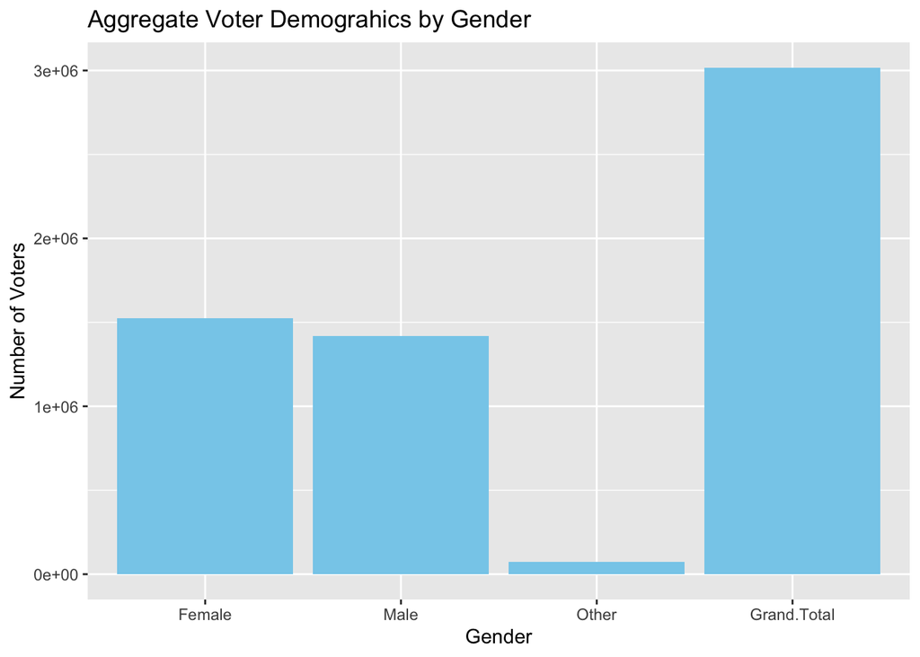

The reason I chose a Bar graph to represent this subsection of the data is that it helps put into perspective the disparities between genders that chose to vote(Female, Male, Other), as well as the Grand Total # of people that voted. Furthermore, given that my data is categorical, a bar graph helps facilitate comparisons between different groups. Within this graph each bar represents a gender with the final bar showing the grand total, and the height of the bar represents the value, or the number of voters, making it easy to compare values at a glance.

### Chart 2

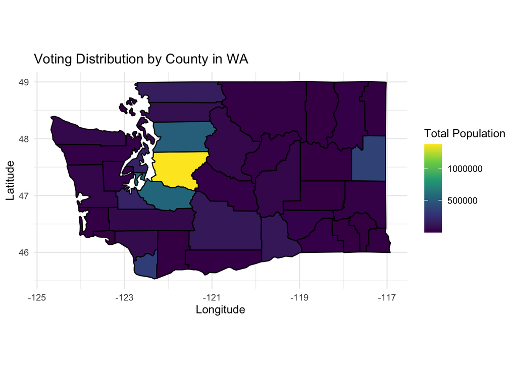

I chose to make a voting distribution map showing the total votes of all genders in different counties in Washington. The reason why I chose to do this is because I think it’s important to show how much of a role region plays in terms of voting population and where majority of votes are coming from. As you can see from the map, King county hosts majority of the population that votes, and the counties surrounding that region are also contributing to a pretty high vote count as well. Another reason why I chose a map chart is because it makes it easier to identify where we could focus on more voting participation and understand how much of an impact a region can sway an election.

### Chart 3

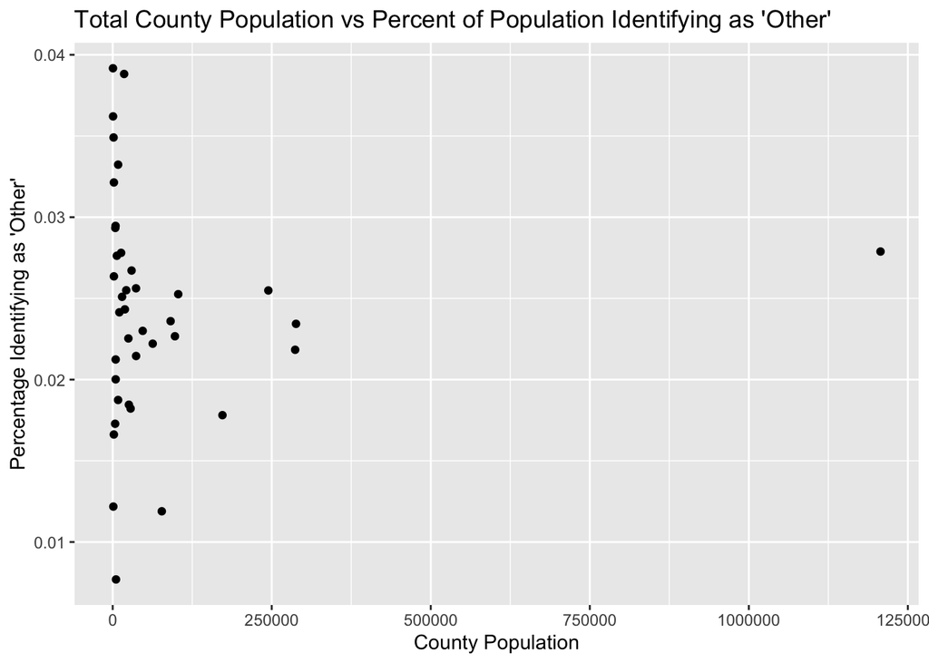

I chose to make a scatter plot showing the poulation of a county and the percentage of people in it that identify their gender as ‘other’. In politics the opinions on many topics can vary largely between more rural and more urban areas. I created this graph to see if ideas around gender identity vary between the more and less populated areas of Washington, and therefore impact the percentage of people who don’t conform to traditional gender identities. I chose a scatter plot because this type of graph most clearly shows the relationship between the two variables, and the overall trend. The data shows very little relation between the two variables, but there is a very slight increase in percentage as the population increases.